# BCB420-A1

Kuan Pang

# 1 Overview

## 1.1 Primary Sjögren’s syndrome(pSS)

- Primary Sjögren’s syndrome (pSS) is a chronic autoimmune disease that affects exocrine glands, such as the tear and saliva glands. The underlying cause of pSS is not fully understood, but it is thought to involve a combination of genetic and environmental factors that trigger an abnormal immune response (Luo et al. 2020). To understand the genetic cause of pSS, we focus on the transcriptomie analysis of exocrine glands from pSS and non-pSS patients.

## 1.2 Patients and Data

- As discussed, we selected GSE159574 from the NCBI GEO database, which consists of RNA sequencing with salivary glands with 16 pSS patients and 13 non-pSS patients. Two subgroups both experienced the subjective clinical symptoms of xerostomia or xerophthalmia while pSS patients fulfill the clinical classification criteria of the pSS. The other group serves as the control for the experiment. The original publication for the dataset is [here](https://www.frontiersin.org/articles/10.3389/fcell.2020.592490/full).

# 2 Setups

## 2.1 Dependencies

- We import the library for the study:

```r
if (!requireNamespace("kableExtra", quietly = TRUE)) {
    install.packages("kableExtra")
}
if (!requireNamespace("edgeR", quietly = TRUE)) {
    install.packages("edgeR")
}
if (!requireNamespace("biomaRt", quietly = TRUE)) {
    install.packages("biomaRt")
}
if (!requireNamespace("ggplot2", quietly = TRUE)) {
    install.packages("ggplot2")
}
if (!requireNamespace("gridExtra", quietly = TRUE)) {
    install.packages("gridExtra")
}
if (!requireNamespace("grid", quietly = TRUE)) {
    install.packages("grid")
}
if (!requireNamespace("dplyr", quietly = TRUE)) {
    install.packages("dplyr")
}
if (!requireNamespace("kableExtra", quietly = TRUE)) {
    install.packages("kableExtra")
}
library(edgeR)
library(biomaRt)
library(ggplot2)
library(gridExtra)
library(grid)
library(dplyr)
library(kableExtra)
```

## 2.2 Dataset

- We retrieve the raw count matrix from the GEO database for analysis.

```r
# accession number
geo_entry <- "GSE159574"
NUM_SAMPLE <- 29
sfiles <- GEOquery::getGEOSuppFiles('GSE159574')
fnames <- rownames(sfiles)

# read raw counts data
pSS_exp <- read.delim(fnames[1],header=TRUE,
                check.names = FALSE)
```

```r
knitr::kable(head(pSS_exp[1:8]), format = "html") %>%
  kable_styling()
```

| Symbol | N1709057 | N1612131 | Y1705161 | N1608171 | Y1611101 | Y1612091 | Y1610271 |
| --- | --- | --- | --- | --- | --- | --- | --- |
| ENSG00000274012 | 2499621 | 2904148 | 5094059 | 3376096 | 5939382 | 3548523 | 1550483 |
| ENSG00000162078 | 1254763 | 1381070 | 1186890 | 930462 | 1302853 | 1255534 | 541588 |
| ENSG00000090382 | 1980221 | 1226872 | 689884 | 510993 | 1191854 | 1774900 | 460282 |
| ENSG00000257764 | 938015 | 549041 | 316671 | 239773 | 576431 | 946961 | 237137 |
| ENSG00000278771 | 118363 | 287071 | 693173 | 399582 | 452449 | 218295 | 425124 |
| ENSG00000171195 | 407407 | 736811 | 94816 | 167489 | 100922 | 160753 | 53156 |

```r
dim(pSS_exp)
```

```
## [1] 58302    30
```

- As shown above, our dataset has 29 samples (16 pSS + 13 non-pSS replicates). The raw count matrix consists of 58302 genes.
- The `Ensembl` gene id is provided in the `Symbol` column and we will map it to HUGO symbols in the later section.

## 2.3 Sample Matrix

- We prepare the sample matrix for downstream analysis.
  - Each sample has a `cond` and `patient` attribute: `cond` stands for pSS condition (`Y` for pSS samples and `N` for non-pSS samples) and `patient` is an unique identifier of the patient.

```r
samples <- data.frame(lapply(colnames(pSS_exp)[2:(NUM_SAMPLE+1)],
        FUN=function(x){unlist(strsplit(x, "(?=[A-Za-z])(?<=[0-9])|(?=[0-9])(?<=[A-Za-z])", perl=TRUE))}))
colnames(samples) <- colnames(pSS_exp)[2:(NUM_SAMPLE+1)]
rownames(samples) <- c("cond","patient")
```

```r
knitr::kable(head(samples[1:8]), format = "html")%>%
  kable_styling()
```

|  | N1709057 | N1612131 | Y1705161 | N1608171 | Y1611101 | Y1612091 | Y1610271 | N1701243 |
| --- | --- | --- | --- | --- | --- | --- | --- | --- |
| cond | N | N | Y | N | Y | Y | Y | N |
| patient | 1709057 | 1612131 | 1705161 | 1608171 | 1611101 | 1612091 | 1610271 | 1701243 |

# 3 Quality Control and Statistics

## 3.1 Feature Filtering

- First, according to the edgeR protocol, we filter out the weakly expressed and non-informative features.
  - We remove features without at least 1 read per million in 13 of the samples, as 13 is the size of the smallest group of replicates.

```r
cpms = cpm(pSS_exp[2:(NUM_SAMPLE+1)])
rownames(cpms) <- pSS_exp[,1]
keep = rowSums(cpms >1) >=13
pSS_exp_filtered = pSS_exp[keep,]
```

```r
dim(pSS_exp_filtered)[1] / dim(pSS_exp)[1]
```

```
## [1] 0.3497993
```

- In this step, we removed ~65% of the features in the dataset.

## 3.2 Statistics

- We plot the density diagram for each samples with per-sample colouring and per-condition coloring.

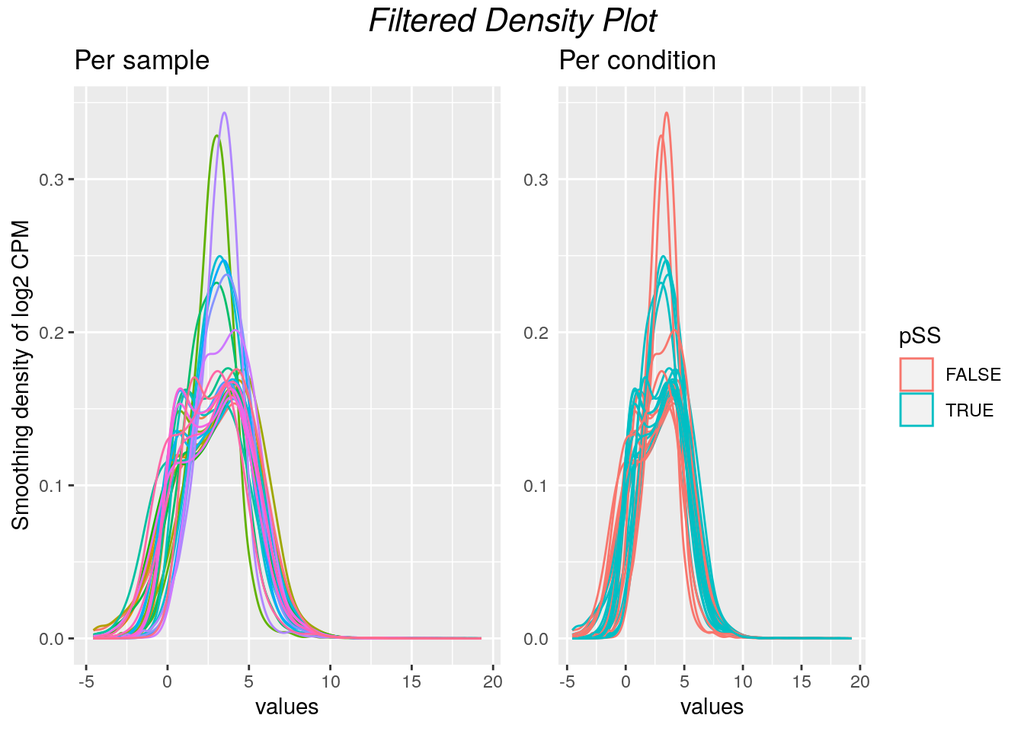

```r
# sample-wise density plot
df <- as.data.frame(log2(cpm(pSS_exp_filtered[2:30])))
df <- stack(df)
df$type <- rep(samples["cond",]=="Y", each=dim(pSS_exp_filtered)[1])
per_sample <- ggplot(data=df, aes(x=values, group=ind, col=ind)) +
    geom_density(adjust=1.5, alpha=.4)+
    ylab("Smoothing density of log2 CPM")+
    ggtitle("Per sample") +
  labs(col="Sample") +
  theme(legend.position = "none")

# condition-wise density plot
per_type <- ggplot(data=df, aes(x=values, group=ind, col=type)) +
    geom_density(adjust=1.5, alpha=.4)+
    # ylab("Smoothing density of log2 CPM")+
    theme(axis.title.y=element_blank(),
          axis.ticks.y=element_blank())   +
    ggtitle("Per condition")+
    labs(col = "pSS")

grid.arrange(per_sample, per_type, ncol=2, top = textGrob("Filtered Density Plot",gp=gpar(fontsize=16,font=3)))
```

## 3.3 Remove Outliers

```r
outliers <- c( "N1701241","N1701063","Y1703072",
               "Y1704141", "Y1702101", "Y1704061")
NUM_SAMPLE <-  NUM_SAMPLE - length(outliers)
corrected_pSS_exp_filtered <- pSS_exp_filtered[, !(colnames(pSS_exp_filtered) %in%  outliers)]
corrected_samples <- samples[,!(colnames(samples) %in%  outliers)]
```

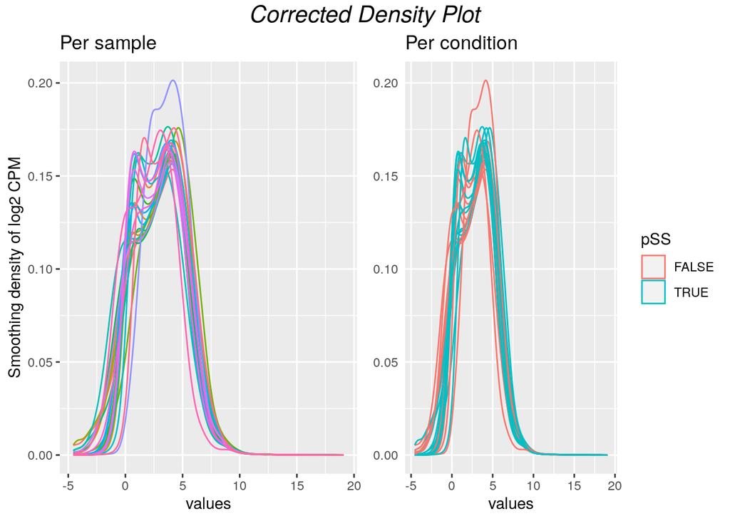

```r
# sample-wise density plot
df <- as.data.frame(log2(cpm(corrected_pSS_exp_filtered[2: (NUM_SAMPLE+1)])))
df <- stack(df)
df$type <- rep(corrected_samples["cond",]=="Y", each=dim(corrected_pSS_exp_filtered)[1])
per_sample <- ggplot(data=df, aes(x=values, group=ind, col=ind)) +
    geom_density(adjust=1.5, alpha=.4)+
    ylab("Smoothing density of log2 CPM")+
    ggtitle("Per sample") +
  labs(col="Sample") +
  theme(legend.position = "none")

# condition-wise density plot
per_type <- ggplot(data=df, aes(x=values, group=ind, col=type)) +
    geom_density(adjust=1.5, alpha=.4)+
    theme(axis.title.y=element_blank(),
          axis.ticks.y=element_blank())   +
    ggtitle("Per condition")+
    labs(col = "pSS")

grid.arrange(per_sample, per_type, ncol=2, top = textGrob("Corrected Density Plot",gp=gpar(fontsize=16,font=3)))
```

- As shown in the previous analysis, a few samples were identified as outliers and removed from further analysis. This was done to ensure that the results were not influenced by these samples and that the data accurately reflected the gene expression patterns in pSS and non-pSS samples. With the outliers removed, the corrected sample matrix now consists of 11 non-pSS and 12 pSS samples. This reduction in sample size may impact the power of the analysis, but it will also reduce the potential for noisy signals and improve the robustness of the results.

# 4 Gene Identifier Mapping

## 4.1 Conversion from `Ensembl` to `HUGO`

- We convert the `Ensembl` gene ids to `HGNC` gene symbols:

```r
ensembl <- useMart("ensembl")
ensembl <- useDataset("hsapiens_gene_ensembl",mart=ensembl)
conversion_stash <- "pSS_id_conversion.rds"
if(file.exists(conversion_stash)){
  pSS_id_conversion <- readRDS(conversion_stash) } else {
  pSS_id_conversion <- getBM(attributes = c("ensembl_gene_id","hgnc_symbol"),
                            filters = c("ensembl_gene_id"),
                            values = corrected_pSS_exp_filtered$Symbol,
                            mart = ensembl)
  saveRDS(pSS_id_conversion, conversion_stash)
}
```

## 4.2 Mapping Results

```r
nrow(corrected_pSS_exp_filtered) -
  length(which(corrected_pSS_exp_filtered$Symbol %in%
                pSS_id_conversion$ensembl_gene_id))
```

```
## [1] 130
```

```r
(nrow(corrected_pSS_exp_filtered) -
  length(which(corrected_pSS_exp_filtered$Symbol %in%
                pSS_id_conversion$ensembl_gene_id))) / nrow(corrected_pSS_exp_filtered)
```

```
## [1] 0.006374424
```

- There are 130 genes that are not successfully converted to the `HGNC` symbols, which is only ~0.6% of our entire filtered dataset

### 4.2.1 Dataset Merge

- We join the gene names into the count matrix:

```r
corrected_pSS_exp_annot <- merge(pSS_id_conversion, corrected_pSS_exp_filtered,
                                 by.x = 1, by.y = 1, all.y = TRUE)
```

```r
knitr::kable(head(corrected_pSS_exp_annot[1:8]), format = "html")%>%
  kable_styling()
```

| ensembl_gene_id | hgnc_symbol | N1709057 | N1612131 | Y1705161 | N1608171 | Y1611101 | Y1612091 |
| --- | --- | --- | --- | --- | --- | --- | --- |
| ENSG00000000003 | TSPAN6 | 3339 | 1858 | 1537 | 3919 | 1888 | 2489 |
| ENSG00000000419 | DPM1 | 791 | 348 | 383 | 527 | 571 | 466 |
| ENSG00000000457 | SCYL3 | 755 | 269 | 356 | 533 | 483 | 447 |
| ENSG00000000460 | C1orf112 | 415 | 134 | 181 | 280 | 229 | 247 |
| ENSG00000000938 | FGR | 44 | 42 | 67 | 71 | 43 | 59 |
| ENSG00000000971 | CFH | 5426 | 1329 | 3294 | 7611 | 3416 | 3968 |

- We examine the values that failed mapping:

```r
kable((corrected_pSS_exp_annot[is.na(corrected_pSS_exp_annot$hgnc_symbol), ]$ensembl_gene_id)[1:8]) %>%
  kable_styling()
```

| x |
| --- |
| ENSG00000112096 |
| ENSG00000116957 |
| ENSG00000130723 |
| ENSG00000133808 |
| ENSG00000170647 |
| ENSG00000182109 |
| ENSG00000182230 |
| ENSG00000182584 |

- The table above shows some selected unmapped `Ensembl` ids. After manual check of unmapped ids:
  - Some values have withdrawn `HGNC` entries, such as `ENSG00000133808`.
  - Some values do not are not included in the conversion database, such as `ENSG00000112096`.
- We discard the unmapped values:

```r
corrected_pSS_exp_annot <- corrected_pSS_exp_annot[!is.na(corrected_pSS_exp_annot$hgnc_symbol), ]
```

### 4.2.2 Check Duplication

- We check the duplicated mapping for each `HGNC` symbols:

```r
kable(sort(table(corrected_pSS_exp_annot$hgnc_symbol)
     [2:length(corrected_pSS_exp_annot$hgnc_symbol)], decreasing=TRUE)[1:3]) %>%
  kable_styling()
```

| Var1 | Freq |
| --- | --- |
| A1BG-AS1 | 1 |
| A1CF | 1 |
| A2M | 1 |

- There are no duplicated mapping between `Ensembl` and `HGNC` symbols.

# 5 Normalization

## 5.1 TMM Normalization

- We applied TMM normalization (weighted trimmed mean of M-values). Since TMM normalization is built on the assumption that the majority of genes are not differentially expressed(Robinson and Oshlack 2010), and this assumption fits our dataset after removing the outliers, we will use TMM as our normalization approach.
- TMM normalization method is implemented in the `edgeR` package (Robinson, McCarthy, and Smyth 2010):

```r
filtered_data_matrix <- as.matrix(corrected_pSS_exp_annot[,3:(NUM_SAMPLE+2)])
rownames(filtered_data_matrix) <- corrected_pSS_exp_annot$hgnc_symbol
exp_d <- DGEList(counts=filtered_data_matrix, group=samples$cond)
```

- Calculate the normalization factors:

```r
exp_d <- calcNormFactors(exp_d, method="TMM")
pSS_normalized_counts <- cpm(exp_d)
```

## 5.2 Normalization Results

### 5.2.1 Density Plot

- We check the normalization results:

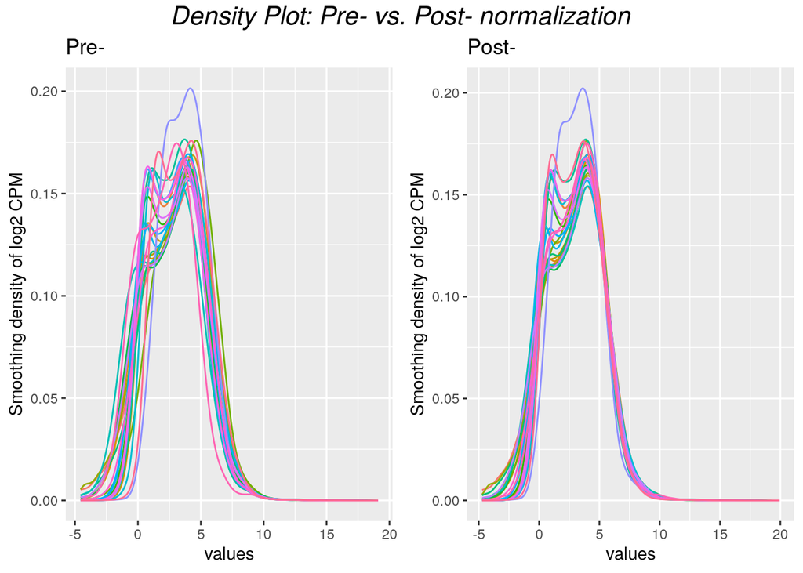

```r
# normalized
df <- as.data.frame(log2(pSS_normalized_counts))
df <- stack(df)
norm_fig <- ggplot(data=df, aes(x=values, group=ind, col=ind)) +
    geom_density(adjust=1.5, alpha=.4)+
    ylab("Smoothing density of log2 CPM")+
    ggtitle("Post-") +
  labs(col="Sample") +
  theme(legend.position = "none")
# pre-normalized
df <- as.data.frame(log2(cpm(corrected_pSS_exp_filtered[2: (NUM_SAMPLE+1)])))
df <- stack(df)
raw_fig <- ggplot(data=df, aes(x=values, group=ind, col=ind)) +
    geom_density(adjust=1.5, alpha=.4)+
    ylab("Smoothing density of log2 CPM")+
    ggtitle("Pre-") +
  labs(col="Sample") +
  theme(legend.position = "none")


grid.arrange(raw_fig, norm_fig, ncol=2, top = textGrob("Density Plot: Pre- vs. Post- normalization",gp=gpar(fontsize=16,font=3)))
```

### 5.2.2 Box plot

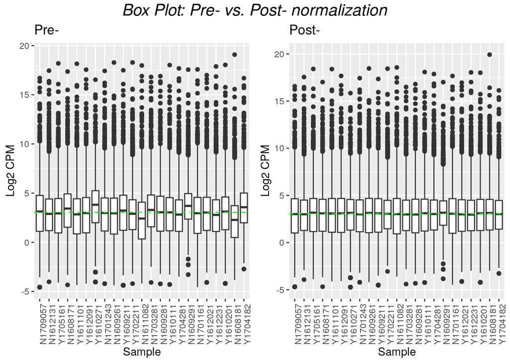

```r
# raw
df <- as.data.frame(log2(cpm(corrected_pSS_exp_filtered[2: (NUM_SAMPLE+1)])))
df <- stack(df)
raw <- ggplot(df, aes(x=ind, y=values))+
  geom_boxplot()+
  xlab("Sample")+
  ylab("Log2 CPM")+
  ggtitle("Pre-")+
  theme(axis.text.x = element_text(angle = 90))+
  geom_hline(yintercept = median(df$values), color = "green", linetype = "dashed")
# normalized
df <- as.data.frame(log2(pSS_normalized_counts))
df <- stack(df)
norm <- ggplot(df, aes(x=ind, y=values))+
  geom_boxplot()+
  xlab("Sample")+
  ylab("Log2 CPM")+
  ggtitle("Post-")+
  theme(axis.text.x = element_text(angle = 90)) +
  geom_hline(yintercept = median(df$values), color = "green", linetype = "dashed")
grid.arrange(raw, norm, ncol=2, top = textGrob("Box Plot: Pre- vs. Post- normalization" ,gp=gpar(fontsize=16,font=3)))
```

- The density plots and box plots comparing the pre-normalized data and the normalized data shown above reveal that normalization has been successful in aligning the distributions of the samples. Before normalization, the pre-normalized data showed significant differences in distribution shapes and central tendencies between samples. However, after normalization, the distributions of the samples are much more aligned, with similar shapes and central tendencies. This result suggests that the normalization process has effectively minimized the technical variation between samples, reducing the impact of technical factors on the results.
- By reducing the technical variation, the normalized data provides a more accurate representation of the biological differences between the pSS and non-pSS samples, allowing for a more robust analysis of gene expression patterns. The improved data quality will increase the reliability of the results and support more confident conclusions about the biology of pSS and non-pSS.

# 6 More EDAs

## 6.1 MDS Plots

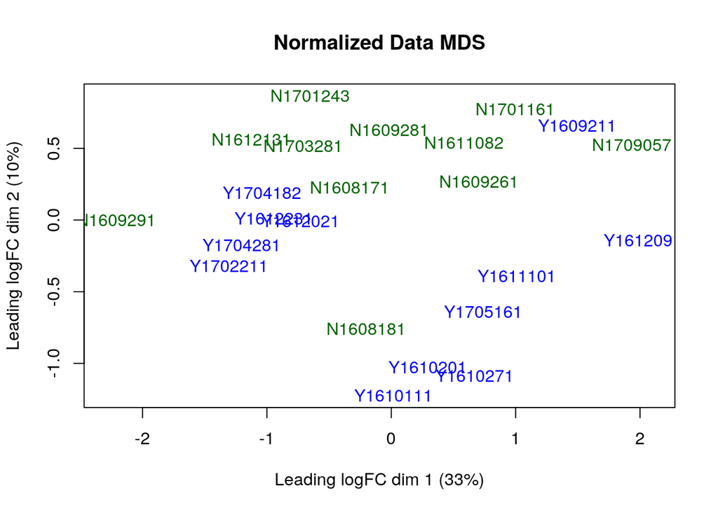

```r
plotMDS(exp_d, labels=colnames(corrected_samples),
  col = c("darkgreen","blue")[factor(corrected_samples["cond",])],
  main="Normalized Data MDS"
  )
```

- The multidimensional scaling plot (MDS) shown above demonstrates that the primary pSS and non-pSS groups do not cluster together as expected. This result suggests the samples from the two groups may not easily distinguished based on their gene expression patterns. However, the plot also reflects that there is some group-wise distance. This result suggests that, despite the lack of clear separation between the two groups, there is still some degree of difference between groups.
- Interestingly, sample `N1608181`, a non-pSS sample, seems to be distanced from the other samples in the same subgroup and is closer to the pSS samples. This observation raises questions about the underlying biology of this sample and whether it may represent a unique subtype of non-pSS. Further investigation may be needed to understand the biological significance of this sample and its relationship to the other samples in the dataset.

## 6.2 Mean-variance Plot

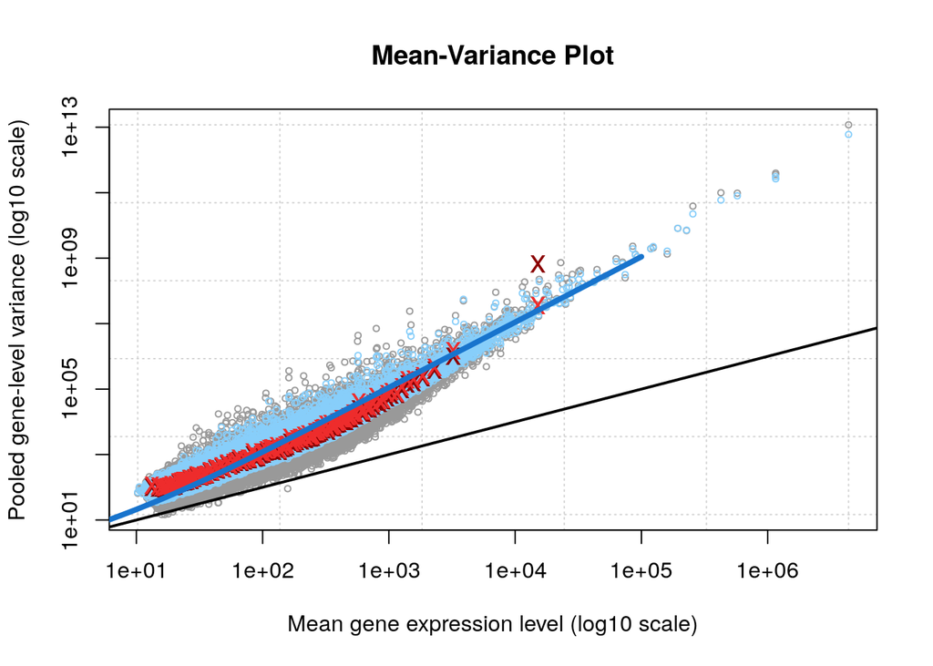

```r
# compute dispersion
exp_d <- estimateCommonDisp(exp_d)
exp_d <- estimateTagwiseDisp(exp_d)
# figure
plotMeanVar(exp_d, show.raw.vars = TRUE, show.tagwise.vars=TRUE,
            show.ave.raw.vars = TRUE,
            NBline=TRUE,
            show.binned.common.disp.vars = TRUE,
            main="Mean-Variance Plot")
```

# 7 Data Persistence

- To make it easier for downstream analysis, we save the processed sample matrix and the expression data as `RDS` file into the parent directory:
  - The file names are: `final_expr_matrix.rds` and `sample_matrix.rds`.

```r
D_SAVE_PATH <- "final_expr_matrix.rds"
saveRDS(pSS_normalized_counts, D_SAVE_PATH)

S_SAVE_PATH <- "sample_matrix.rds"
saveRDS(corrected_samples, S_SAVE_PATH)
```

# 8 Journal & Extra information

- Extra information, including dataset selection, is discussed in course journal [here](https://github.com/bcb420-2023/Kuan_Pang/wiki/4.A1).

# 9 Interpretation and Analysis

> What are the control and test conditions of the dataset?
- As discussed in Patients and Data, samples are biopsied from pSS patients and non-pSS individuals. In this case, pSS samples would be considered the test condition, and non-pSS samples would be considered the control condition.

> Why is the dataset of interest to you?
- As discussed in Primary Sjögren’s syndrome(pSS), Primary Sjögren’s syndrome (pSS) is a chronic autoimmune disease characterized by damage to the exocrine glands and extra-glandular involvements (Luo et al. 2020). Understanding the underlying biology of pSS is important for improving diagnosis and treatment of this debilitating disease. Studying the gene expression patterns in pSS patients can provide valuable insights into the molecular mechanisms and support the development of new diagnostics.

> Were there expression values that were not unique for specific genes? How did you handle these?
- All the expressions values are uniquely mapped to genes after filtering, each `Ensembl` id is mapped to a unique `HGNC` symbol, as discussed in Mapping Results.

> Were there expression values that could not be mapped to current HUGO symbols?
- There are 130 expression values that are not mapped to the current `HGNC` symbols, since it is only ~0.6% of our dataset, we simply discard them from the downstream analysis. See Mapping Results for details, including investigation into the missing values.

> How many outliers were removed?
- Six samples were removed from our dataset as a result of our analysis. As previously demonstrated in Remove Outliers, the majority of samples (~80%) showed a bimodal distribution, while six other samples displayed an abnormally high single peak. While the original publication did not mention these outliers, we think the deviation from the expected distribution pattern suggests potential technical issues with these samples, and we have treated them as outliers and removed them from further analysis. By doing so, we have ensured that the results of our analysis are based on high-quality data and the conclusions drawn from the analysis are robust.

> How did you handle replicates?
- After removing outlier replicates, we performed TMM normalization (Robinson and Oshlack 2010) to minimize the technical variations among samples. We have observed more consistent and low-variant distribution across biological replicates. Figures in Normalization supplements our arguments.

# 10 Reference

Luo, Jing, Xin Liao, Lihe Zhang, Xin Xu, Senhong Ying, Mengjiao Yu, Lixia Zhu, Suxian Lin, and Xiaobing Wang. 2020. “Transcriptome Sequencing Reveals Potential Roles of ICOS in Primary Sjögren’s Syndrome.” *Frontiers in Cell and Developmental Biology* 8: 592490.

Robinson, Mark D, Davis J McCarthy, and Gordon K Smyth. 2010. “edgeR: A Bioconductor Package for Differential Expression Analysis of Digital Gene Expression Data.” *Bioinformatics* 26 (1): 139–40.

Robinson, Mark D, and Alicia Oshlack. 2010. “A Scaling Normalization Method for Differential Expression Analysis of RNA-Seq Data.” *Genome Biology* 11 (3): 1–9.